# Metro LPHA Region Report

12/09/2020

**Prepared by the Colorado COVID-19 Modeling Group**  
Colorado School of Public Health: Andrea Buchwald, Elizabeth Carlton, Debashis Ghosh, Irina Kasarskis, Jonathan Samet, Laura Timm, Emily Wu; University of Colorado School of Medicine: Kathryn Colborn; University of Colorado-Boulder Department of Applied Mathematics: Sabina Altus, David Bortz; University of Colorado-Denver: jimi adams; Colorado State University: Jude Bayham

For Contact: Jon.Samet@CUAnschutz.edu

This report is generated based on hospitalization data through 11/30/2020. Due to lags between infection and hospitalization, estimates of transmission control and the effective reproductive number represent the spread of infections through approximately 11/17/2020.

Estimated number of infections to date: Approximately 15.6% of the Metro Region population has been infected to date.

Estimated current level of transmission control: 71% for the period of 11/09 to 11/23.

There is an approximate 71% reduction in total transmission-relevant contacts, including reductions due to mask-wearing, physical distancing, contact tracing, self-isolation, and all other policy and behavioral changes compared to uncontrolled transmission, as in the very early days of the pandemic. The threshold value for transmission control varies by region. For the Metro region, the threshold is 75%.

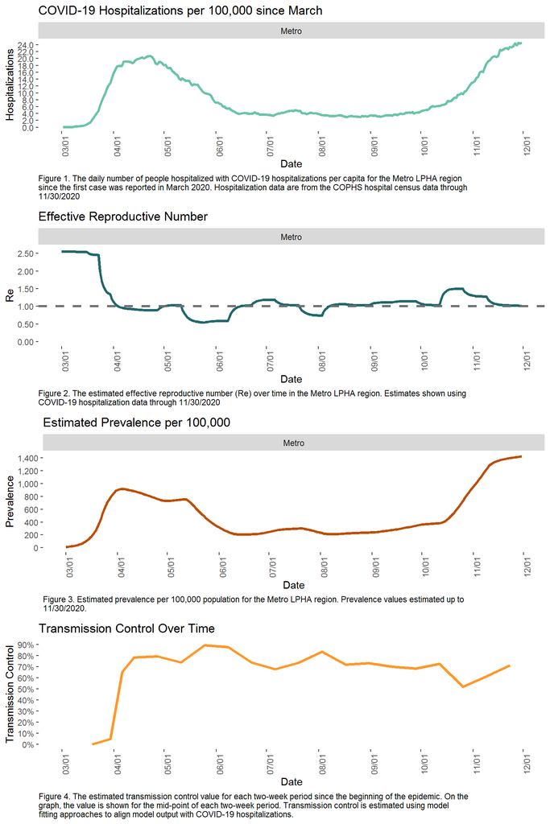